# Modelling longitudinal data: the individual approach

Marc Lavielle January 27, 2014

### The data

Let us consider a dose D = 50mg of a drug administered orally to a patient at time $t=0$. The concentration of the drug in the bloodstream $(y_j, 1\leq j \leq 12)$ is then measured at times $(t_j, 1\leq j \leq 12)$:

First, we import the data stored in the data file `individualFitting_data.txt` and plot it to have an initial look:

```r
pk1=read.table("individualFitting_data.txt",header=T)
pk1
```

```
##    time concentration
## 1   0.5          0.94
## 2   1.0          1.30
## 3   1.5          1.64
## 4   2.0          3.38
## 5   3.0          3.72
## 6   4.0          3.29
## 7   8.0          1.31
## 8  10.0          0.80
## 9  12.0          0.39
## 10 16.0          0.31
## 11 20.0          0.10
## 12 24.0          0.09
```

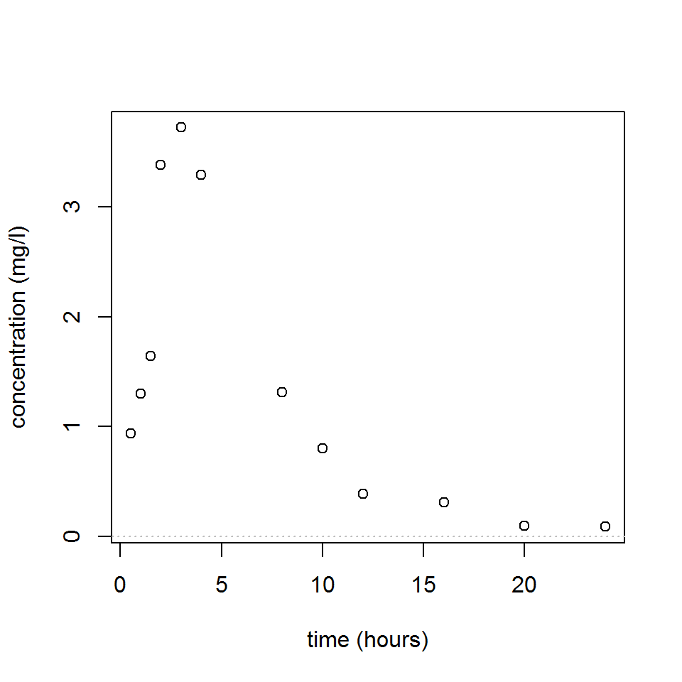

```r
t=pk1$time
y=pk1$concentration
n=length(t)
plot(t,y,xlab="time (hours)",ylab="concentration (mg/l)")
abline(a=0,b=0,lty=3,col="grey")
```

### Fitting two PK models

$\def\ka{k_a} \def\kel{k} \def\teps{\varepsilon}$

We are going to consider two possible structural models that may describe the observed time-course of the concentration:

- A one-compartment model with first-order absorption and first-order elimination: $\begin{aligned} \phi_1 &= (\ka, V, \kel) \\ f_1(t ; \phi_1) &= \frac{D\, \ka}{V(\ka-\kel)} \left( e^{-\kel \, t} - e^{-\ka \, t} \right). \end{aligned}$

```r
predc1=function(t,x){
   f=50*x[1]/x[2]/(x[1]-x[3])*(exp(-x[3]*t)-exp(-x[1]*t))
return(f)}
```

- A one-compartment model with zero-order absorption and first-order elimination: $\begin{aligned} \phi_2 &= (T_{k0}, V, \kel) \\ f_2(t ; \phi_2) &= \left\{ \begin{array}{ll} \frac{D}{V \,T_{k0} \, \kel} \left( 1- e^{-\kel \, t} \right) & {\rm if }\ t\leq T_{k0} \\[0.3cm] \frac{D}{V \,T_{k0} \, \kel} \left( 1- e^{-\kel \, T_{k0}} \right)e^{-\kel \, (t- T_{k0})} & {\rm otherwise} . \end{array} \right. \end{aligned}$

```r
predc2=function(t,x){
   f=50/x[1]/x[2]/x[3]*(1-exp(-x[3]*t))
   f[t>x[1]]=50/x[1]/x[2]/x[3]*(1-exp(-x[3]*x[1]))*
     exp(-x[3]*(t[t>x[1]]-x[1]))
return(f)}
```

We then define two models ${\cal M}_1$ and ${\cal M}_2$ that assume (for now) constant residual error models: $\begin{aligned} {\cal M}_1 : \quad y_j & = f_1(t_j ; \phi_1) + a_1\teps_j \\ {\cal M}_2 : \quad y_j & = f_2(t_j ; \phi_2) + a_2\teps_j . \end{aligned}$

We can fit these two models to our data by computing the maximum likelihood estimate (MLE) $\hat{\psi}_1=(\hat{\phi}_1,\hat{a}_1)$ and $\hat{\psi}_2=(\hat{\phi}_2,\hat{a}_2)$ of $\psi$ under each model. We can use the `nlm` function for nonlinear minimization. This function requires an initial value $\psi_0 = (\phi_0, a_0)$:

```r
fmin1=function(x,y,t){
   f=predc1(t,x)
   g=x[4]
   e=sum( ((y-f)/g)^2 + log(g^2))
return(e)}

fmin2=function(x,y,t){
   f=predc2(t,x)
   g=x[4]
   e=sum( ((y-f)/g)^2 + log(g^2))
return(e)}

options(warn=-1)
pk.nlm1=nlm(fmin1, c(0.3,6,0.2,1), y, t, hessian="true")
psi1=pk.nlm1$estimate
pk.nlm2=nlm(fmin2, c(3,10,0.2,4), y, t, hessian="true")
psi2=pk.nlm2$estimate

cat(" psi1 =",psi1,"\n","psi2 =",psi2)
```

```
##  psi1 = 0.3240916 6.001204 0.3239337 0.4366948
##  psi2 = 3.203111 8.999746 0.229977 0.2555242
```

### Evaluating and selecting PK models

The estimated parameters $\hat{\phi}_1$ and $\hat{\phi}_2$ can then be used for computing the predicted concentrations $\hat{f}_1(t)$ and $\hat{f}_2(t)$ under both models at any time $t$. These curves can be plotted over the original data and compared:

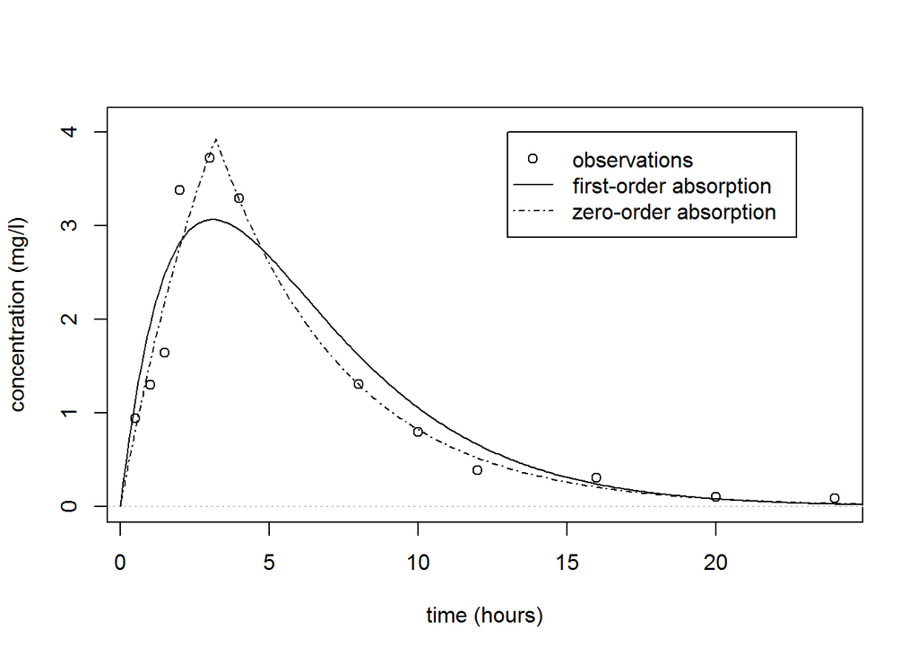

```r
tc=seq(from=0,to=25,by=0.1)
phi1=psi1[c(1,2,3)]
fc1=predc1(tc,psi1)
phi2=psi2[c(1,2,3)]
fc2=predc2(tc,psi2)

plot(t,y,ylim=c(0,4.1),xlab="time (hours)",ylab="concentration (mg/l)")
lines(tc,fc1, type = "l", col = "black", lwd=1, lty=1)
lines(tc,fc2, type = "l", col = "black", lwd=1, lty=4)
abline(a=0,b=0,lty=3,col="grey")
legend(13,4,
       c("observations","first-order absorption","zero-order absorption"),
       lty=c(-1,1,4), pch=c(1,-1,-1), lwd=1)
```

We clearly see that a much better fit is obtained with model ${\cal M}_2$, i.e., assuming a zero-order absorption process.

Another useful goodness-of-fit plot can be obtained by plotting the observations $(y_j)$ versus the predictions $\hat{y}_j=f(t_j ; \hat{\psi})$ given by the models:

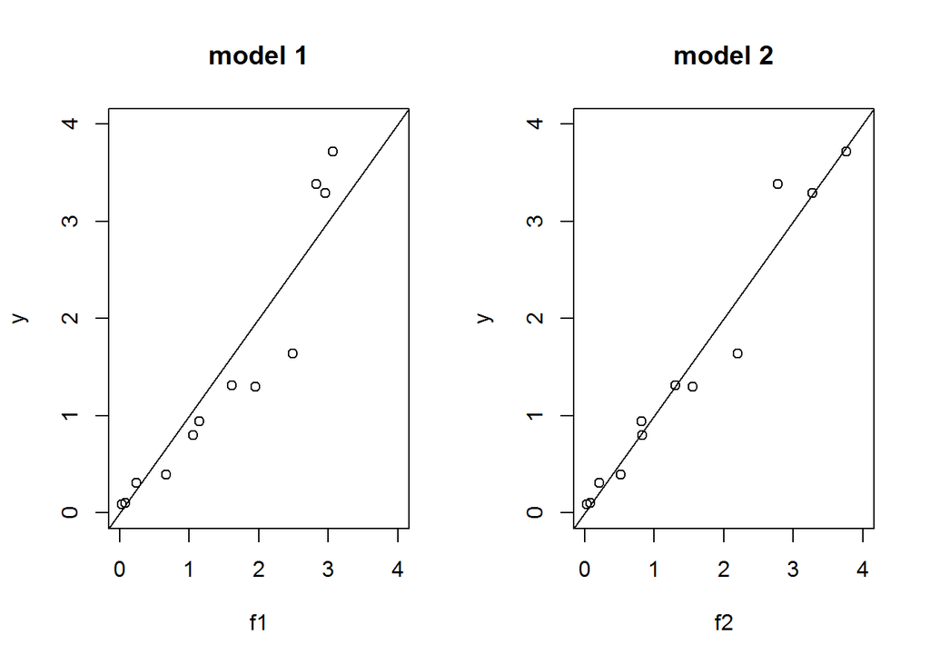

```r
f1=predc1(t,phi1)
f2=predc2(t,phi2)

par(mfrow= c(1,2))
plot(f1,y,xlim=c(0,4),ylim=c(0,4), main="model 1")
abline(a=0,b=1,lty=1)
plot(f2,y,xlim=c(0,4),ylim=c(0,4), main="model 2")
abline(a=0,b=1,lty=1)
```

### Model selection

```r
deviance1=pk.nlm1$minimum + n*log(2*pi)
bic1=deviance1+log(n)*length(psi1)
deviance2=pk.nlm2$minimum + n*log(2*pi)
bic2=deviance2+log(n)*length(psi2)
cat(" bic1 =",bic1,"\n","bic2 =",bic2)
```

```
##  bic1 = 24.10972
##  bic2 = 11.24769
```

A smaller BIC is better. Therefore, this result also suggests that model ${\cal M}_2$ should be selected.

### Fitting different error models

For the moment, we have only considered constant error models. However, the *observations vs predictions* plot hints that the amplitude of the residual errors may increase with the size of the predicted value. Let us therefore take a closer look at four different residual error models, each of which we will associate with the *best* structural model $f_2$:

${\cal M}_2$ constant error model: $y_j=f_2(t_j;\phi_2)+a_2\teps_j$

${\cal M}_3$ proportional error model: $y_j=f_2(t_j;\phi_3)+b_3f_2(t_j;\phi_3)\teps_j$

${\cal M}_4$ combined error model: $y_j=f_2(t_j;\phi_4)+(a_4+b_4f_2(t_j;\phi_4))\teps_j$

${\cal M}_5$ exponential error model: $\log(y_j)=\log(f_2(t_j;\phi_5)) + a_5\teps_j$.

The three new ones need to be entered into R:

```r
fmin3=function(x,y,t){
   f=predc2(t,x)
   g=x[4]*f
   e=sum( ((y-f)/g)^2 + log(g^2))
return(e)}

fmin4=function(x,y,t){
   f=predc2(t,x)
   g=abs(x[4])+abs(x[5])*f
   e=sum( ((y-f)/g)^2 + log(g^2))
return(e)}

fmin5=function(x,y,t){
   f=predc2(t,x)
   g=x[4]
   e=sum( ((log(y)-log(f))/g)^2 + log(g^2))
return(e)}
```

We can now compute the MLEs $\hat{\psi}_3=(\hat{\phi}_3,\hat{b}_3)$, $\hat{\psi}_4=(\hat{\phi}_4,\hat{a}_4,\hat{b}_4)$ and $\hat{\psi}_5=(\hat{\phi}_5,\hat{a}_5)$ of $\psi$ under models ${\cal M}_3$, ${\cal M}_4$ and ${\cal M}_5$:

```r
pk.nlm3=nlm(fmin3, c(phi2,0.1), y, t, hessian="true")
psi3=pk.nlm3$estimate

pk.nlm4=nlm(fmin4, c(phi2,1,0.1), y, t, hessian="true")
psi4=pk.nlm4$estimate
psi4[c(4,5)]=abs(psi4[c(4,5)])

pk.nlm5=nlm(fmin5, c(phi2,0.1), y, t, hessian="true")
psi5=pk.nlm5$estimate

cat(" psi3 =",psi3,"\n","psi4 =",psi4,"\n","psi5 =",psi5)
```

```
##  psi3 = 2.642409 11.44113 0.1838779 0.2189221
##  psi4 = 2.890066 10.16836 0.2068221 0.02741416 0.1456332
##  psi5 = 2.710984 11.2744 0.188901 0.2310001
```

### Selecting the error model

As before, these curves can be plotted over the original data and compared:

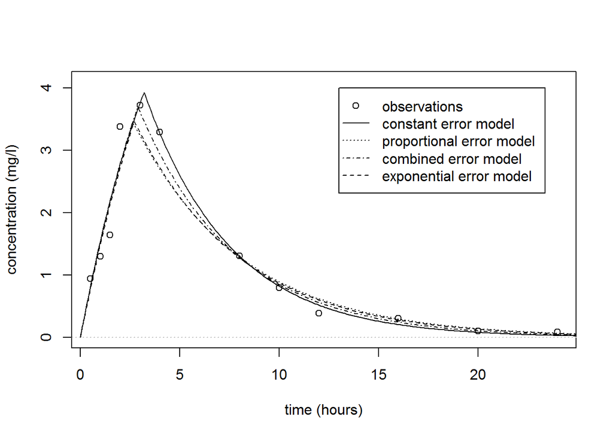

```r
phi3=psi3[c(1,2,3)]
fc3=predc2(tc,phi3)
phi4=psi4[c(1,2,3)]
fc4=predc2(tc,phi4)
phi5=psi5[c(1,2,3)]
fc5=predc2(tc,phi5)

par(mfrow= c(1,1))
plot(t,y,ylim=c(0,4.1),xlab="time (hours)",ylab="concentration (mg/l)")
lines(tc,fc2, type = "l", lwd=1)
lines(tc,fc3, type = "l", lwd=1, lty=3)
lines(tc,fc4, type = "l", lwd=1, lty=4)
lines(tc,fc5, type = "l", lwd=1, lty=2)
abline(a=0,b=0,lty=3,col="grey")
legend(13,4,c("observations","constant error model",
      "proportional error model", "combined error model",
      "exponential error model"), lty=c(-1,1,3,4,2), pch=c(1,-1,-1,-1,-1))
```

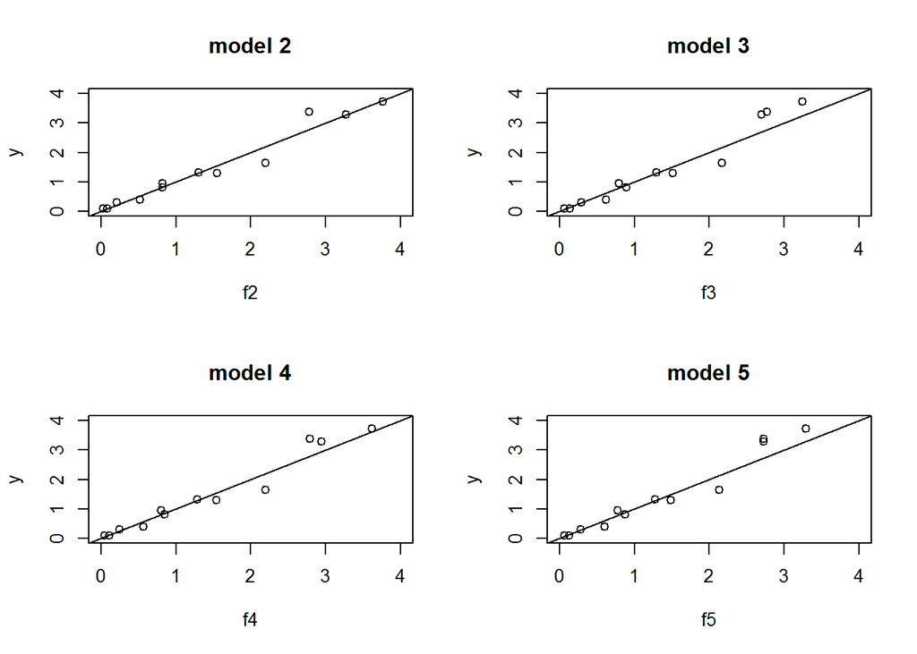

```r
f2=predc2(t,phi2)
f3=predc2(t,phi3)
f4=predc2(t,phi4)
f5=predc2(t,phi5)

par(mfrow= c(2,2))
plot(f2,y,xlim=c(0,4),ylim=c(0,4), main="model 2")
abline(a=0,b=1,lty=1)
plot(f3,y,xlim=c(0,4),ylim=c(0,4), main="model 3")
abline(a=0,b=1,lty=1)
plot(f4,y,xlim=c(0,4),ylim=c(0,4), main="model 4")
abline(a=0,b=1,lty=1)
plot(f5,y,xlim=c(0,4),ylim=c(0,4), main="model 5")
abline(a=0,b=1,lty=1)
```

The predicted concentrations obtained with models ${\cal M}_3$, ${\cal M}_4$ and ${\cal M}_5$ are quite similar. We now calculate the BIC for each:

```r
deviance3=pk.nlm3$minimum + n*log(2*pi)
bic3=deviance3 + log(n)*length(psi3)
deviance4=pk.nlm4$minimum + n*log(2*pi)
bic4=deviance4 + log(n)*length(psi4)
deviance5=pk.nlm5$minimum + 2*sum(log(y)) + n*log(2*pi)
bic5=deviance5 + log(n)*length(psi5)

cat(" bic3 =",bic3,"\n","bic4 =",bic4,"\n","bic5 =",bic5)
```

```
##  bic3 = 3.443607
##  bic4 = 3.475841
##  bic5 = 4.108521
```

All of these BIC are lower than the constant residual error one.

There is not however a large difference between them, though the proportional and combined error models give the smallest and essentially identical BIC. We will use the combined error model ${\cal M}_4$ in the following (the same types of analyses could be done with the proportional error model).

A 90% confidence interval for $\psi_4$ can derived from the Hessian (i.e., the square matrix of second-order partial derivatives) of the objective function (i.e., -2 $\times \ LL$):

```r
alpha=0.9
df=n-length(phi4)
I4=pk.nlm4$hessian/2
H4=solve(I4)
s4=sqrt(diag(H4)*n/df)
delta4=s4*qt(0.5+alpha/2,df)
ci4=matrix(c(psi4-delta4,psi4+delta4),ncol=2)
print(ci4)
```

```
##             [,1]        [,2]
## [1,]  2.22576690  3.55436561
## [2,]  7.93442421 12.40228967
## [3,]  0.16628224  0.24736196
## [4,] -0.02444571  0.07927403
## [5,]  0.04119983  0.25006660
```

We can also calculate a $90\%$ confidence interval for $f_4(t)$ using the central limit theorem:

```r
nlpredci=function(phi,f,H){
   dphi=length(phi)
   nf=length(f)
   H=H*n/(n-dphi)
   S=H[seq(1,dphi),seq(1,dphi)]
   G=matrix(nrow=nf,ncol=dphi)
   for (k in seq(1,dphi)) {
      dk=phi[k]*(1e-5)
      phid=phi
      phid[k]=phi[k] + dk
      fd=predc2(tc,phid)
      G[,k]=(f-fd)/dk
   }
   M=rowSums((G%*%S)*G)
   deltaf=sqrt(M)*qt(0.5+alpha/2,df)
return(deltaf)}

deltafc4=nlpredci(phi4,fc4,H4)
```

This can then be plotted:

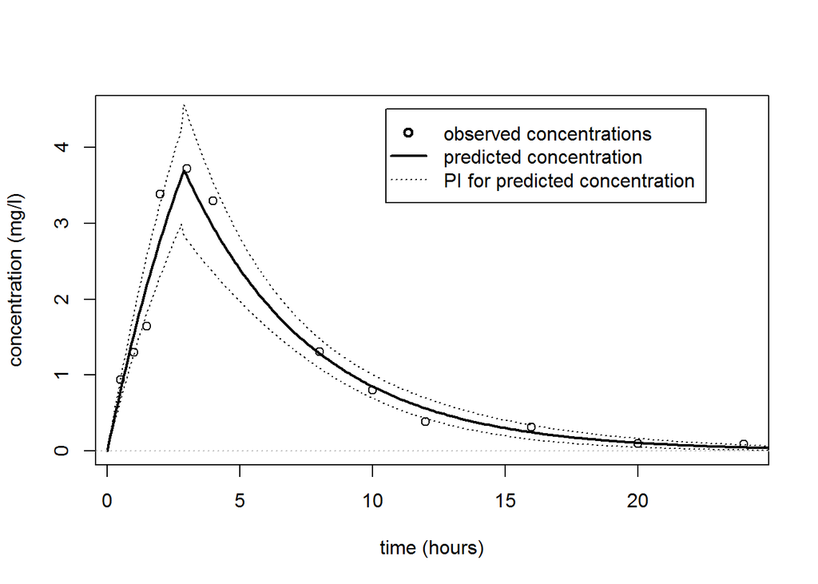

```r
par(mfrow= c(1,1))
plot(t,y,ylim=c(0,4.5),xlab="time (hours)",ylab="concentration (mg/l)")
lines(tc,fc4, type = "l", lwd=2)
lines(tc,fc4-deltafc4, type = "l", lwd=1, lty=3)
lines(tc,fc4+deltafc4, type = "l", lwd=1, lty=3)
abline(a=0,b=0,lty=3,col="grey")
legend(10.5,4.5,c("observed concentrations","predicted concentration",
  "PI for predicted concentration"),lty=c(-1,1,3), pch=c(1,-1,-1), lwd=c(2,2,1))
```

Alternatively, prediction intervals for $\hat{\psi}_4$, $\hat{f}_4(t;\hat{\psi}_4)$ and new observations at any time $t$ can be estimated by Monte Carlo simulation:

```r
f=predc2(t,phi4)
a4=psi4[4]
b4=psi4[5]
g=a4+b4*f
dpsi=length(psi4)
nc=length(tc)
N=500
qalpha=c(0.5 - alpha/2,0.5 + alpha/2)
PSI=matrix(nrow=N,ncol=dpsi)
FC=matrix(nrow=N,ncol=nc)
Y=matrix(nrow=N,ncol=nc)
for (k in seq(1,N)) {
   eps=rnorm(n)
   ys=f+g*eps
   pk.nlm=nlm(fmin4, psi4, ys, t)
   psie=pk.nlm$estimate
   psie[c(4,5)]=abs(psie[c(4,5)])
   PSI[k,]=psie
   fce=predc2(tc,psie[c(1,2,3)])
   FC[k,]=fce
   gce=a4+b4*fce
   Y[k,]=fce + gce*rnorm(1)
}

mean4s=apply(PSI,2,mean)
median4s=apply(PSI,2,median)
sd4s=apply(PSI,2,sd)
ci4s=matrix(nrow=dpsi,ncol=2)
for (k in seq(1,dpsi)){
   ci4s[k,]=quantile(PSI[,k],qalpha,names=FALSE)
}
print(matrix(c(mean4s,median4s,sd4s),nrow=dpsi))
```

```
##             [,1]       [,2]       [,3]
## [1,]  2.91134719  2.8942184 0.34482632
## [2,] 10.12644320 10.1376755 1.09132255
## [3,]  0.20869823  0.2073007 0.01786742
## [4,]  0.02671244  0.0192332 0.02905856
## [5,]  0.11449193  0.1192890 0.05226249
```

```r
print(ci4s)
```

```
##              [,1]        [,2]
## [1,] 2.410982e+00  3.51041736
## [2,] 8.490447e+00 11.92530977
## [3,] 1.832408e-01  0.23705995
## [4,] 7.680649e-09  0.08095676
## [5,] 1.542693e-02  0.19760731
```

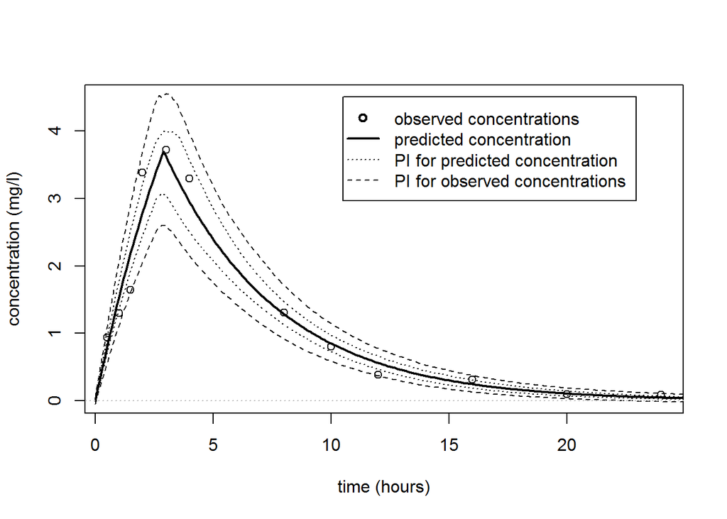

```r
cifc4s=matrix(nrow=nc,ncol=2)
ciy4s=matrix(nrow=nc,ncol=2)
for (k in seq(1,nc)){
   cifc4s[k,]=quantile(FC[,k],qalpha,names=FALSE)
   ciy4s[k,]=quantile(Y[,k],qalpha,names=FALSE)
}

par(mfrow= c(1,1))
plot(t,y,ylim=c(0,4.5),xlab="time (hours)",ylab="concentration (mg/l)")
lines(tc,fc4, type = "l", lwd=2)
lines(tc,cifc4s[,1], type = "l", lwd=1, lty=3)
lines(tc,cifc4s[,2], type = "l", lwd=1, lty=3)
lines(tc,ciy4s[,1], type = "l",  lwd=1, lty=2)
lines(tc,ciy4s[,2], type = "l",  lwd=1, lty=2)
abline(a=0,b=0,lty=3,col="grey")
legend(10.5,4.5,c("observed concentrations","predicted concentration",
       "PI for predicted concentration","PI for observed concentrations"),
       lty=c(-1,1,3,2), pch=c(1,-1,-1,-1), lwd=c(2,2,1,1))
```